# First Analysis

Niels

24 February, 2026

# 1 Overview

- 00 ReadMe
- 01 First Analysis

# 2 Data Input and Setup

## 2.1 Libraries

Inputing the needed libraries for this file.

```r
library(dplyr) # provides useful functions including %>% option...
library(ggplot2)
library(histova)
```

## 2.2 Paths

Read in the needed data for this notebook.

Set the path locations.

```r
# these are the directories that the project will be accessing... the structure will vary based on project needs
# (I had certain data that could and could not be saved on the share drive due to PPI)
# the design is that one only needs to specify the main 'root' directories - in this case pathLaptop & pathShare
# and everything will fall under those two locations... Could just as easily only have one root directory location
# though it might be useful to have a folder storing GBs of R analysis files on your local computer for access times
# and space considerations on the share drive (if the raw data is safely backed up and the R analysis data would take
# a few days to rebuild I would assess that as low risk & decently secure)
#
# !!!!!!!!!!!!!!!!!!!!!!!!!!!!!!!!!!!!!!!!!!!!!!!!!!!!!!!!!!!!!!!!!!!!!!!!!!!!!!!!!!!!!!!!!!!!!!!!!!!!!!!!!!!!!!!!!!!!!
# IF you are using git to manage your file make sure that the .gitignore file is correctly configured                 !
# you likely do not want to be backing up (or trying to) your actual data files to whatever git repo you are using... !
# !!!!!!!!!!!!!!!!!!!!!!!!!!!!!!!!!!!!!!!!!!!!!!!!!!!!!!!!!!!!!!!!!!!!!!!!!!!!!!!!!!!!!!!!!!!!!!!!!!!!!!!!!!!!!!!!!!!!!
#
pathLaptop = "/Users/path/to/your/folder/"
pathLaptop.rData = "Projects-rData/"
pathLaptop.clin = "Project-clinData/"

# this directory gets synced with the share drive every 30min.
# outside of the renv library directory all files are 'released' onto the share drive...
pathShare = "/Volumes/path/to/your/share/folder/"
pathShare.out = "output/"
pathShare.csv = "csv/"
```

Set the script colors.

```r
library(RColorBrewer)
# look at some settings...
#display.brewer.all(colorblindFriendly = TRUE)
#brewer.pal(n=5,name="Dark2")

colors.diag = c("setosa" = RColorBrewer::brewer.pal(n=6, name="Paired")[1], "versicolor" = RColorBrewer::brewer.pal(n=6, name="Paired")[3],
               "virginica" = RColorBrewer::brewer.pal(n=6, name="Paired")[6]
              )
colors.stratum = c("changed" = RColorBrewer::brewer.pal(n=4, name="Dark2")[4], "no" = "grey")

shapes.diag = c("setosa" = 17, "versicolor" = 0, "virginica" = 1)
```

## 2.3 Functions

```r
# this also sets the tblMap and other basic table display variables used in this script...
source(here::here("scripts", "03-Analysis_Functions.R"), local= knitr::knit_global())
```

## 2.4 Data

Read in the R data that has been saved previously:

```r
# read in the saved data (in R format)
# commented out because there is no data...
#load(paste0(pathLaptop, pathLaptop.rData, 'R_data_filename.rda')) # clinData, clinData.labels
```

# 3 Results

Since I’m just dumping default R data out I’m skipping any modeling or anlysis that would typically be happening and jumping directly to figures…

```r
data(iris)
```

## 3.1 Figures

Just doing this to show a useful *tabset* option to save space on a html output and allow quick review of related figures… Adding the tabset to the header above makes all subheads that follow tabs under this header…. This is escaped by the next ‘##’ header…

### 3.1.1 histova

Implementation of histova: a basic histogram + ANOVA tool I put together. This is designed less for a markdown file but more for ability to use text based data input files to generate histograms where changing the appearance settings in one file can be transferred to all subsequent files for consistency. The project is still under active development to enable modification of settings, saving of settings, and toggling log output for better markdown display…

[output not shown]

[output not shown]

[output not shown]

[output not shown]

[output not shown]

[output not shown]

[output not shown]

[output not shown]

[output not shown]

[output not shown]

[output not shown]

[output not shown]

[output not shown]

```
##         TWO TAILED REMOVAL on group G1 (value 19, p.val: 2.34e-03)
```

[output not shown]

[output not shown]

[output not shown]

[output not shown]

[output not shown]

[output not shown]

[output not shown]

[output not shown]

[output not shown]

[output not shown]

[output not shown]

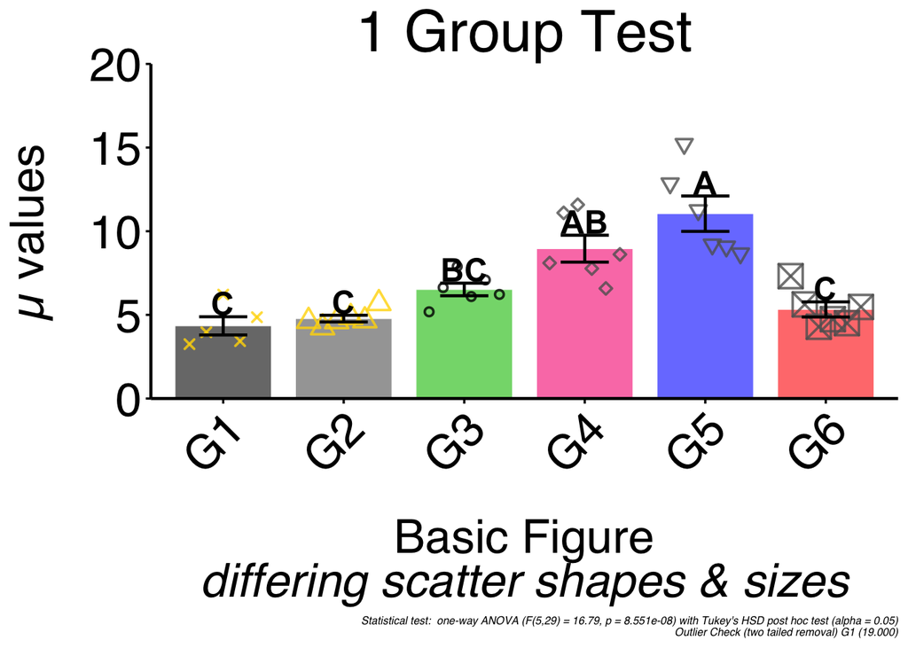

[output not shown]

```r
# devtools::install_github("smallwerke/histova") # install the package

d = getwd()
#d = "/Users/M278784/Documents/Statistics/R_Project_Template"
f = "test-1_group-ANOVA_scatter_outlier.txt"

#d

generate_figure(d,f, printPlot = TRUE, savePlot = FALSE, saveLog = FALSE)
```

### 3.1.2 Sepal

Can specify how this code block displays the figures generated within by setting width & height…

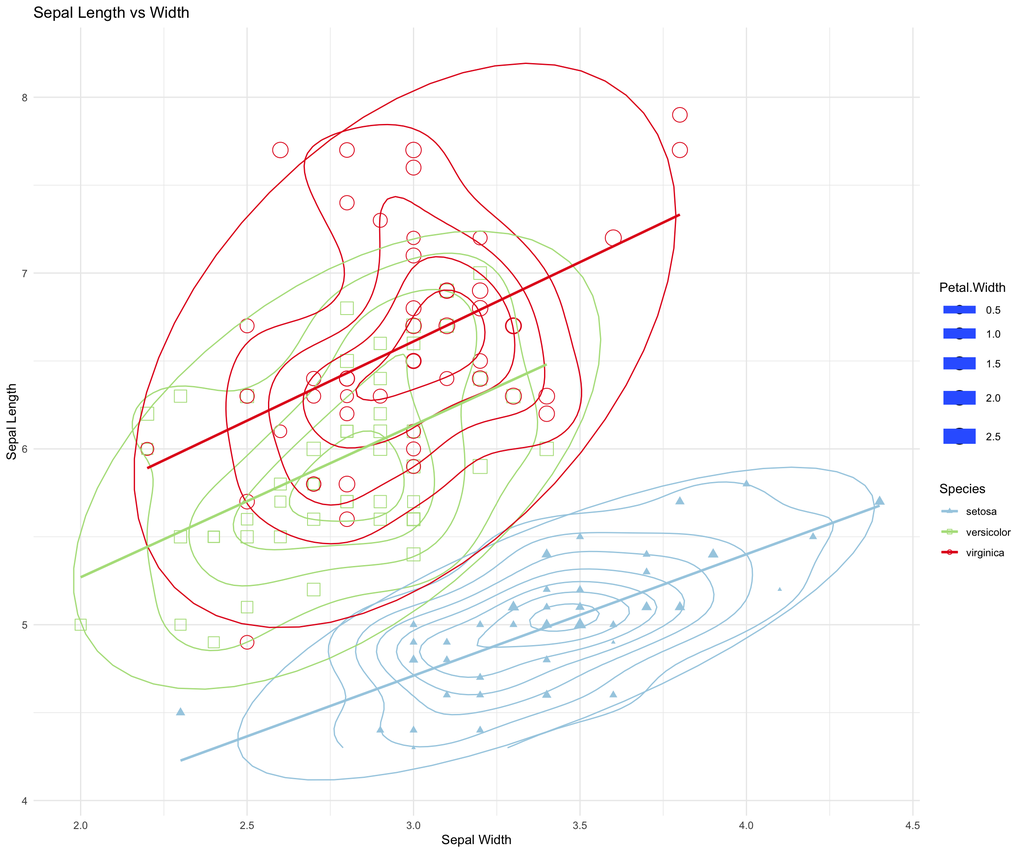

```r
iris %>% ggplot(aes(y = Sepal.Length, x = Sepal.Width, color = Species, shape=Species)) +
  geom_point(aes(size=Petal.Width)) +
  #geom_point() +
  labs(title="Sepal Length vs Width", y="Sepal Length", x = "Sepal Width") +
  scale_color_manual(values=colors.diag) +  scale_shape_manual(values=shapes.diag) + theme_minimal() +
  geom_density2d()  +
  stat_ellipse(type="norm") +
  geom_smooth(method=lm, se=F)
```

### 3.1.3 Petal

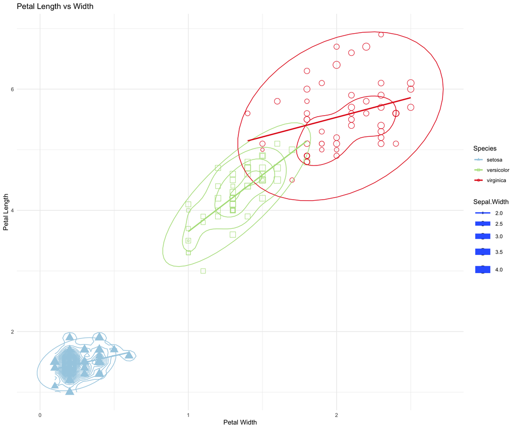

```r
iris %>% ggplot(aes(y = Petal.Length, x = Petal.Width, color = Species, shape=Species)) +
  geom_point(aes(size=Sepal.Width)) +
  #geom_point() +
  labs(title="Petal Length vs Width", y="Petal Length", x = "Petal Width") +
  scale_color_manual(values=colors.diag) +  scale_shape_manual(values=shapes.diag) + theme_minimal() +
  geom_density_2d(contour_var = "density", bins=30)  +
  stat_ellipse(type="norm") +
  geom_smooth(method=lm, se=F)
```